# Economics—“One” Way to Find Fraud

# Foundational Concepts

In today’s lecture, we’re going to be talking about economics. Economics is certainly one of the most common arenas in which we think of statistical data as being centrally important, and it is.

```r
library(TSA)
```

[output not shown]

```r
def_sym("X", "Y", "CPI_CY", "CMBCY", "CMBBY", "phi", "e_t", "Y_t_p")

cmStats <- modules::use("CmStats.R")$cmStats
```

Economics is one of the most common arenas in which statistical data are important. Data arise when we measure incomes and wealth, the balance of trade, the de cit, the stock market, the consumer price index, and employment levels. All these data are indications of the economic condition of the world and make real differences in our daily lives. The consumer price index in uences such things as tax rates and Social Security bene ts. Looking at historical trends is a suggestive method of getting a sense of how the world is changing. However, in some cases, looking at historical trends is a poor method for predicting the future. For example, it is a bad strategy to buy mutual funds based on last year’s performance. A surprising feature of tables of data in economics is that the leading digits of numbers do not occur with equal frequency. This unexpected reality, whose full formation is called Benford’s Law, gives us an unexpected statistical method for detecting fraud.

### CPI

```r
# cost of living in dollar per item an the following years.
cost_of_living_df <-  tibble(
  items = c("coffe", "gas", "rent"),
  metrics = c("kg", "gallons", "month"),
  quantity_basket = c(10, 50, 1),
  prices_Y_2020 = c(4.00, 3.00, 1000.00),
  prices_Y_2025 = c(5.00, 4.00, 1100.00),
  )
cost_of_living_df
```

| items | metrics | quantity_basket | prices_Y_2020 | prices_Y_2025 |
| --- | --- | --- | --- | --- |
| coffe | kg | 10 | 4 | 5 |
| gas | gallons | 50 | 3 | 4 |
| rent | month | 1 | 1000 | 1100 |

The CPI is an important economic indicator. The CPI measures the change over time in the price of the items that people buy in day-to-day living. The basic idea of the CPI is that it looks at how much various items cost from month to month. If the cost of items goes up, then the CPI records the amount more that we must pay to purchase the same items. The CPI has the goal of giving a sense about how much, more or less, it costs real people in the United States to buy a cross-section of goods and services. To produce the CPI, a speci ed collection of goods and services is used, called the market basket. Each month, people go out and see how much it would cost to buy that market basket. The cost from month to month is compared.

```r
cpi_cy = CMBCY/(CMBBY * 100)
CPI_CY
```

```
c: CPI_CY
```

```r
cpi_cy
```

```
c:   CMBCY
   ─────────
   100⋅CMBBY
```

```r
cpi <-  subs(
  cpi_cy,
  list(CMBCY = sum(cost_of_living_df$prices_Y_2025 * cost_of_living_df$quantity_basket),
       CMBBY = sum(cost_of_living_df$prices_Y_2020 * cost_of_living_df$quantity_basket)))
cpi
```

```
c:  27
   ────
   2380
```

```r
N(cpi, digits = 5)
```

```
c: 0.011345
```

There are certainly many features that complicate the simple basic idea of the CPI. One change is that people buy different things as different products come on the market. It would not be sensible to compare only the items in the 1965 market basket with the costs of those same items today. Some items produced then would not be purchased today at all. Many items, such as computer-based goods, would not have been invented in 1965, yet form a signi cant part of consumer purchasing today. All these features lead to complicated strategies for adding and removing items from the market basket. If, over a certain number of years, it costs twice as much to buy the same collection of things, then we would be able to assert that in ation has doubled the prices. The CPI, then, gives us a sense of what a dollar is worth.

### Data mining

Data mining refers to the process of looking at an existing collection of data to nd patterns or trends. Data mining can be a very valuable strategy for identifying features of the world; however, there are dangers. In large sets of data, we expect there to be patterns that occur by random chance alone. We would also expect rare events to occur by chance. The appropriate use of data mining is to nd patterns, then undertake new experiments to con rm or reject the hypothesis suggested by the mined data.

An analogy that makes this point very clearly is the lottery. Suppose that, among investment strategies, we included buying lottery tickets. We would find that, among the possible investments, there was one $1 investment that earned $100 million. Following the logic of investing in the manner that worked best last year, we would invest in lottery tickets—perhaps we would choose to select the same numbers as the winning ticket. This investment decision is unlikely to be a good one.

**Benford’s Law.**

Data mining leads us to an interesting phenomenon in economics: Benford’s Law. Physicist Frank Benford did a study of some 20,000 various data sets of numbers and discovered that approximately 30% of the numbers began with 1, rather than about 11%, as expected (1 out of 9). He formulated Benford’s Law: The proportion of numbers beginning with 1 is

```r
log10(1 + 1/1)
```

```
[1] 0.30103
```

with 3 digits:

```r
log10(1 + 1/3)
```

```
[1] 0.1249387
```

and so forth, until with 9, when the proportion is:

```r
log10(1 + 1/9)
```

```
[1] 0.04575749
```

f you doubt the veracity of this law, pick a random list of numbers and you will likely see that the number 1 appears disproportionately often as the lead number.

Let’s take an example. Suppose you deposit $1.00 in a bank account that offers a 10%-per-year growth rate. In looking at your growing deposit through the years, you will nd a preponderance of leading 1s at rst, because when we start with a number that begins with 1, 10% more still has a leading 1, 10% more still does, and so forth. When you arrive at numbers starting with the digit 2, you start to make bigger jumps, so you have fewer numbers with leading 2s, and so forth until you arrive at the teens; at that point, you are back to leading 1s for quite some time as compared to the 20s, 30s, and so forth. If we begin with a number that starts with, say, 9, then 10% often pushes it beyond starting with 9 and definitely does so on the next occurrence.

This lecture has presented some familiar economic indicators. Much of the way we measure our financial situation involves statistical presentations of the economic conditions of our lives. We must interpret data appropriately to know where we stand. Because dollars change in value over time, comparing a dollar from one time with a dollar from another does not capture the meaning we seek. We must be careful to avoid the pitfalls of drawing inappropriate conclusions from data-mining methods.

# Concept and Applications

## TIME SERIES ANALYSIS

Time series analysis gives us a way to model response data that’s correlated with itself from one point in time to the next—data that has a time dependence. To analyze that type of data, we need new methods that can model a dependency on time. We’ve traditionally looked at modeling the relationship of ( predictor ) X versus ( response ) Y, whether by linear, polynomial, or logistic regression. But now, we have a single measurement from a population and we want to understand how that measurement changes over time. Time is the independent predictor variable. Our goal is to understand how our response, Y, varies with respect to time.

### TIME SERIES

A time series is a collection of evenly spaced numerical observations that are measured successively in time.

The 3 main goals of time series analysis are to describe ( identify patterns, trends, and seasonal variation ), explain ( understand and model the data ), and forecast ( predict short-term trends from previous patterns ).

Statisticians are especially interested in understanding the underlying structure so that they can forecast future values. The goal is to develop a statistical model that describes and explains the data in such a way that forecasting can occur.

The data file “wages” contains monthly values of the average hourly wages ( in dollars ) for workers in the U.S. apparel and textile products industry for July 1981 through June 1987.

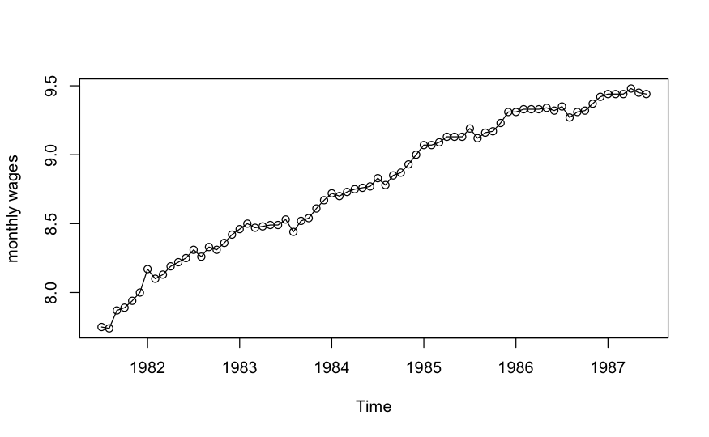

```r
data(wages)
plot(wages, ylab="monthly wages", type="o")
```

Notice that this plot shows a strong increasing trend, perhaps linear or quadratic. If we didn’t know that this was a time series, we would fit a linear regression to the data, look for a significant predictor, and check the residuals for normality and independence using quantile-quantile ( Q-Q ) plots. ۧ Time series analysis follows in much the same way: Fit a line to the ۧ data as a function of time ( predictor ) and check the residuals ( what’s left over from the fit ). They should look like noise ( not have any pattern or trend ).

```r
wages_lm = lm(wages ~ time(wages))
summary(wages_lm)
```

```
Call:
lm(formula = wages ~ time(wages))

Residuals:
     Min       1Q   Median       3Q      Max
-0.23828 -0.04981  0.01942  0.05845  0.13136

Coefficients:
              Estimate Std. Error t value Pr(>|t|)
(Intercept) -5.490e+02  1.115e+01  -49.24   <2e-16 ***
time(wages)  2.811e-01  5.618e-03   50.03   <2e-16 ***
---
Signif. codes:  0 ‘***’ 0.001 ‘**’ 0.01 ‘*’ 0.05 ‘.’ 0.1 ‘ ’ 1

Residual standard error: 0.08257 on 70 degrees of freedom
Multiple R-squared:  0.9728,    Adjusted R-squared:  0.9724
F-statistic:  2503 on 1 and 70 DF,  p-value: < 2.2e-16
```

With a multiple R2 of 97% and highly significant regression coefficients, the case might appear to be closed. But let’s make sure that our residuals don’t have any trend in them.

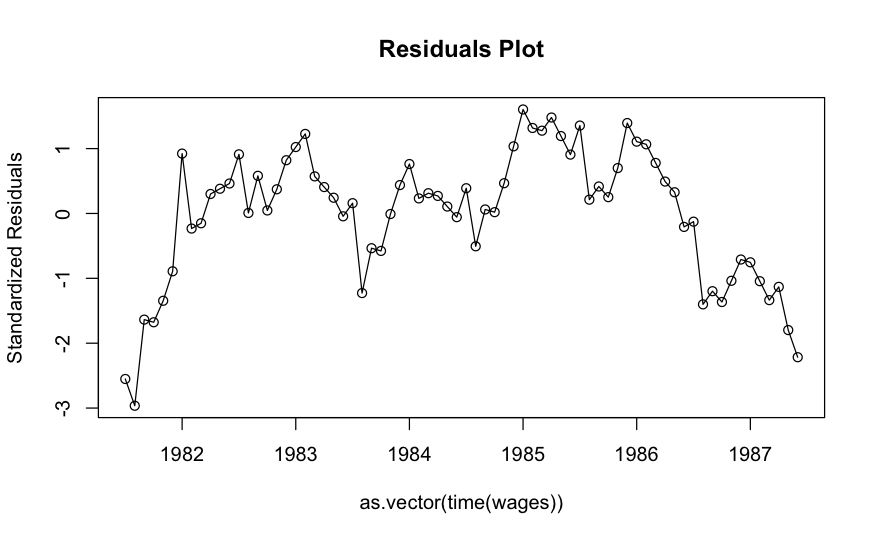

```r
y <-  rstandard(wages_lm)
plot(y, x=as.vector(time(wages)),
ylab='Standardized Residuals',type='o',
main="Residuals Plot")
```

- For residuals, the desirable result is that their correlation is 0. In other words, residuals should be unrelated to each other.
- These residuals don’t look random at all. They hang together too closely, suggesting that there’s still more structure to be removed from the data. Let’s try a quadratic fit on the wages time series.

```r
wages_lm2 <- lm(wages ~ time(wages) + I(time(wages)^2))
summary(wages_lm2)
```

```
Call:
lm(formula = wages ~ time(wages) + I(time(wages)^2))

Residuals:
      Min        1Q    Median        3Q       Max
-0.148318 -0.041440  0.001563  0.050089  0.139839

Coefficients:
                   Estimate Std. Error t value Pr(>|t|)
(Intercept)      -8.495e+04  1.019e+04  -8.336 4.87e-12 ***
time(wages)       8.534e+01  1.027e+01   8.309 5.44e-12 ***
I(time(wages)^2) -2.143e-02  2.588e-03  -8.282 6.10e-12 ***
---
Signif. codes:  0 ‘***’ 0.001 ‘**’ 0.01 ‘*’ 0.05 ‘.’ 0.1 ‘ ’ 1

Residual standard error: 0.05889 on 69 degrees of freedom
Multiple R-squared:  0.9864,    Adjusted R-squared:  0.986
F-statistic:  2494 on 2 and 69 DF,  p-value: < 2.2e-16
```

Again, based on the regression summary and an R2 of 0.986, it appears as if we might have the best model. Let’s look at the residuals.

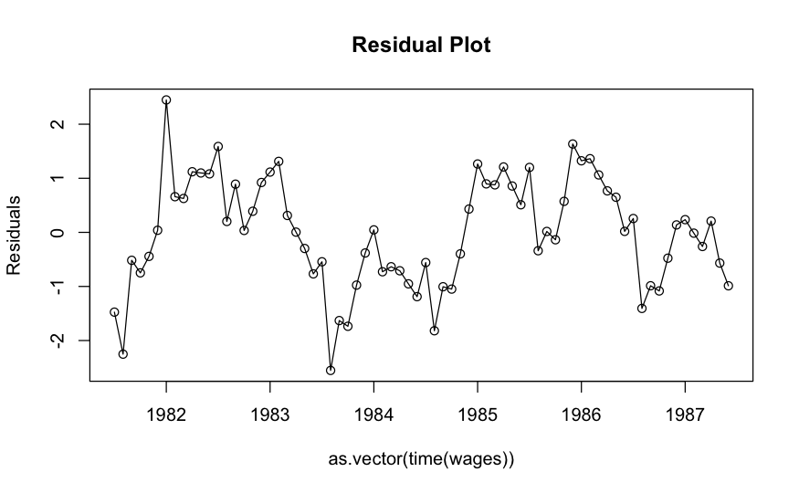

```r
y <-  rstandard(wages_lm2)
plot(y, x = as.vector(time(wages)), ylab='Standardized
Residuals', type='o', main="Residual Plot")
```

There still appears to be some structure in the residuals. Let’s check them for normality.

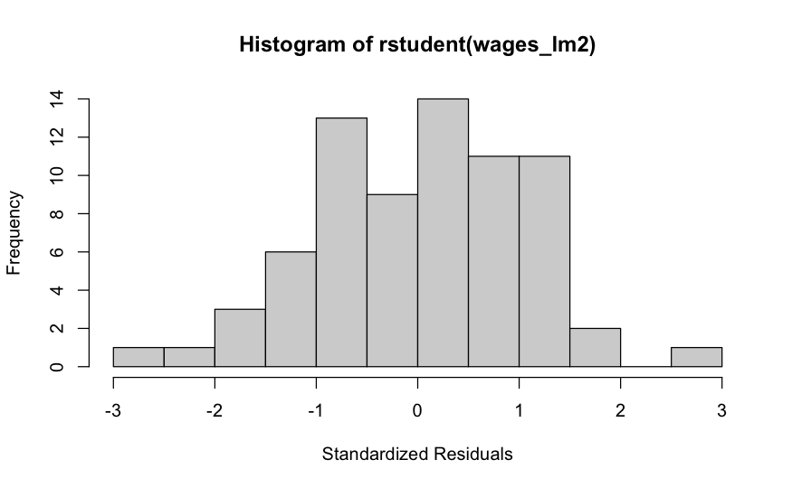

```r
hist(rstudent(wages_lm2), xlab='Standardized Residuals')
```

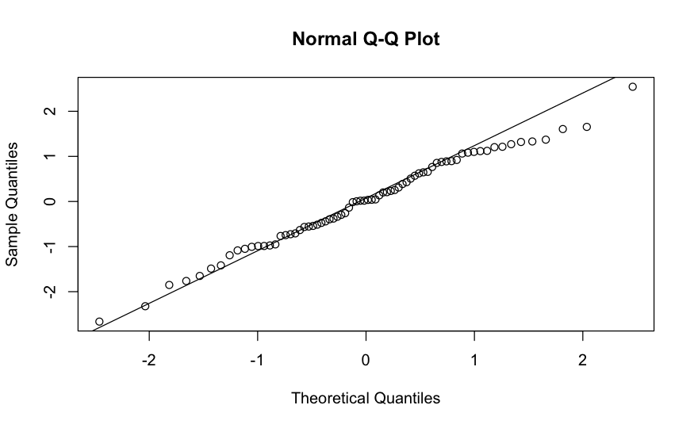

```r
qqnorm(rstudent(wages_lm2))
qqline(rstudent(wages_lm2))
```

```r
shapiro.test(rstudent(wages_lm2))
```

```
    Shapiro-Wilk normality test

data:  rstudent(wages_lm2)
W = 0.98868, p-value = 0.7693
```

### TYPES OF MODELS

The basic objective usually is to determine a model that describes ۧ the pattern of the time series. Let’s consider the 2 types of models for the pattern in a time series: autoregressive models and moving average models.

Autoregressive ( AR ) models are ones that relate the present value of a series to past series values. That is called an AR( 𝑝 ), an autoregressive model of order 𝑝, where 𝑝 is basically the number of lags and the number of steps you’re going to look into the past.

```r
phi*cmStats$Y + phi_p * Y_t_p + e_t
```

```
c: Y⋅φ + Yₜ ₚ⋅φₚ + eₜ
```

Theoretically, the AR( 1 ) model is written as

```r
phi*Y_t_p + e_t
```

```
c: Yₜ ₚ⋅φ + eₜ
```

A 𝜙 at 0.9 is a strong dependence on the previous point whereas a 𝜙 at 0.1 is not getting much information from the neighboring point.

The assumptions of the AR( 1 ) model are that the errors are independently distributed with a normal distribution that has mean 0 and constant variance and that the errors are independent of Yt.

Moving average ( MA ) models are ones that relate the present value of a series to past prediction errors.

```r
e_t + Theta*e_t_1 + Theta * e_t_q
```

```
c: Θ⋅eₜ ₁ + Θ⋅e_t_q + eₜ
```

These past prediction errors have to be estimated by nonlinear methods and are known as moving average terms in the model.

In the MA( q ) way of thinking, the observations of a random variable at time t are affected by the shock at time t( et ) and by the shocks that have taken place before time t.

Together, these time series models are called autoregressive moving average ( ARMA ) models, which provide one of the basic tools in time series modeling.

When we include differencing ( taking the difference of Yt − Yt−1 ), we get autoregressive integrated moving average ( ARIMA ) models. ARIMA series often have an underlying linear trend and sometimes contain seasonality, which is cyclical fluctuations that reoccur seasonally throughout a year.

### SEASONAL SERIES

The other common pattern in a time series dataset is seasonality, which is any kind of periodicity.

A time series repeats itself after a regular period of time. The business cycle plays an important role in economics. In time series analysis, the business cycle is typically represented by a seasonal ( or periodic ) model.

A smallest time period for this repetitive phenomenon is called a seasonal period, s. We use s to denote periodicity of a seasonal time series.

The monthly airline passenger time series, first investigated by George Box and Gwilym Jenkins in 1976, is considered a classic time series. Let’s check out the time series plots of the original series.

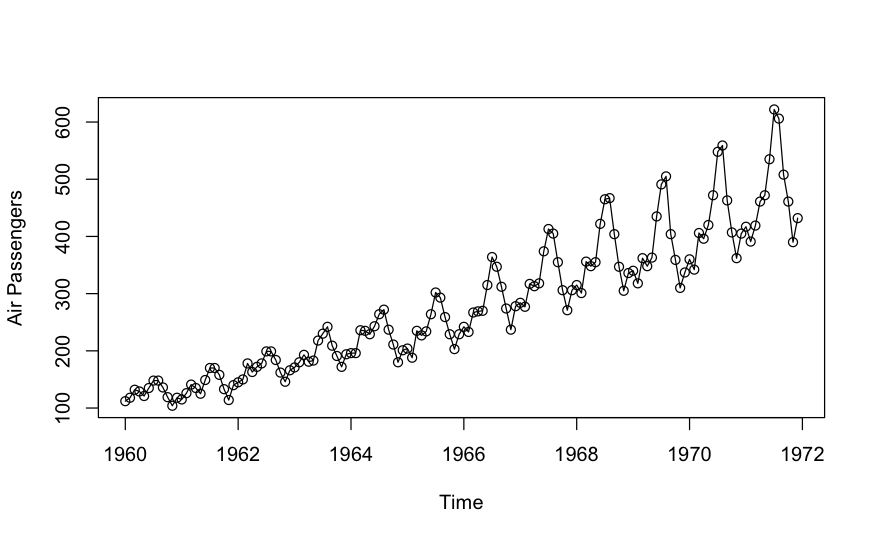

```r
plot(airpass, type='o',ylab='Air Passengers')
```

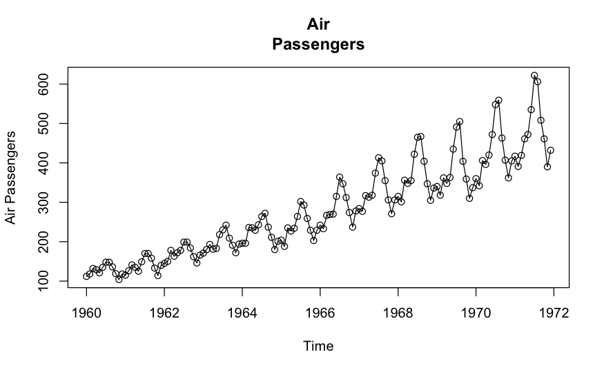

```r
plot(airpass, type='o',ylab='Air Passengers', main="Air
Passengers")
```

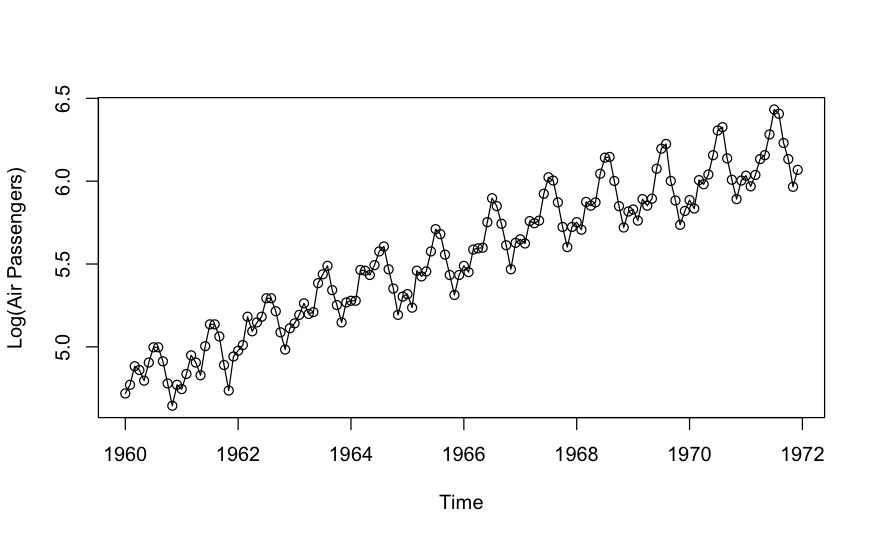

```r
plot(log(airpass), type='o',ylab='Log(Air Passengers)')
```

The graph of the logarithms displays a much more constant variation around the upward trend. Check out the change in values on the 𝑦-axis: 100 to 600 down to 4.5 to 6.5. Notice that the log transformation has removed the increasing variability, or heteroscedasticity.

The first difference of a time series is the series of changes from one period to the next. If Yt denotes the value of the time series Y at period t, then the first difference of Y at period t is equal to Yt − Yt−1.

We use differencing methods to model and remove the effect of trends ( linear, quadratic, etc. ) in the data. Let’s check out the time series plots of the first difference of the log series.

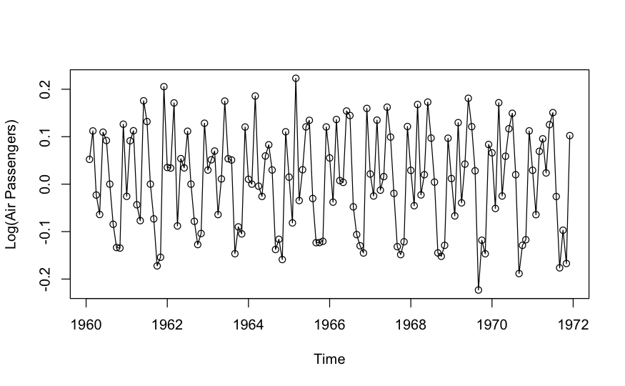

```r
plot(diff(log(airpass)),type='o',ylab='Difference of
Log(Air Passengers)')
```

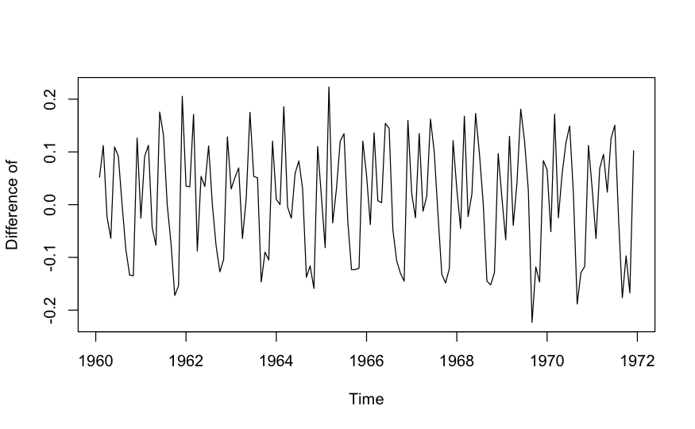

```r
plot(diff(log(airpass)),type='l',ylab='Difference of')
```

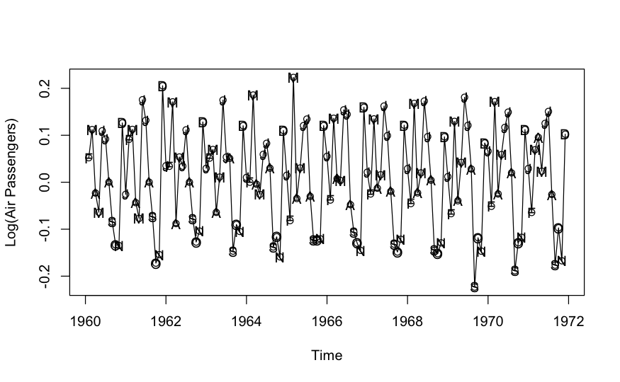

```r
plot(diff(log(airpass)),type='o',ylab='Difference of
Log(Air Passengers)')
points(diff(log(airpass)),x=time(diff(log(airpass))),pch=
as.vector(season(diff(log(airpass)))))
```

The seasonality can be observed by looking at the plotting symbols carefully. Septembers, Octobers, and Novembers are mostly at the low points, and Decembers are mostly at the high points. ۧ ۧ Let’s check out the time series plot of the seasonal difference of the first difference of the logged series.

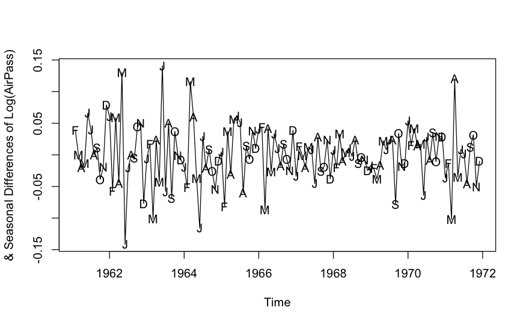

```r
plot(diff(diff(log(airpass)),lag=12),type='l',ylab='First
& Seasonal Differences of Log(AirPass)')
points(diff(diff(log(airpass)),lag=12),x=time(diff(diff(log(airpass)),lag=12)),
pch=as.vector(season(diff(diff(log(airpass)),lag=12))))
```

- We chose to do the plot with seasonal plotting symbols. The seasonality is much less obvious now. Some Decembers are high and some are low. Similarly, some Octobers are high and some are low.
- We’ve accounted for the structure in our data through taking the log, the first difference, and the first seasonal difference.

### SAMPLE AUTOCORRELATION FUNCTION

How much is this time series correlated with itself? The sample autocorrelation function ( ACF ) can give us an answer.

Here, the ACF gives correlations between the series 𝑦t and lagged values of the series for lags of 1, 2, 3, and so on. This is a visual plot of 𝜌1, 𝜌2, …. The ACF can be used to identify the possible structure of time series data. That can be tricky because there often isn’t a single clear-cut interpretation of a sample ACF.

In a different way, the ACF of the residuals for a model is also useful. The ideal for an ACF of residuals is that there aren’t any significant correlations for any lag, because then your model has taken into account all of the structure in the data.

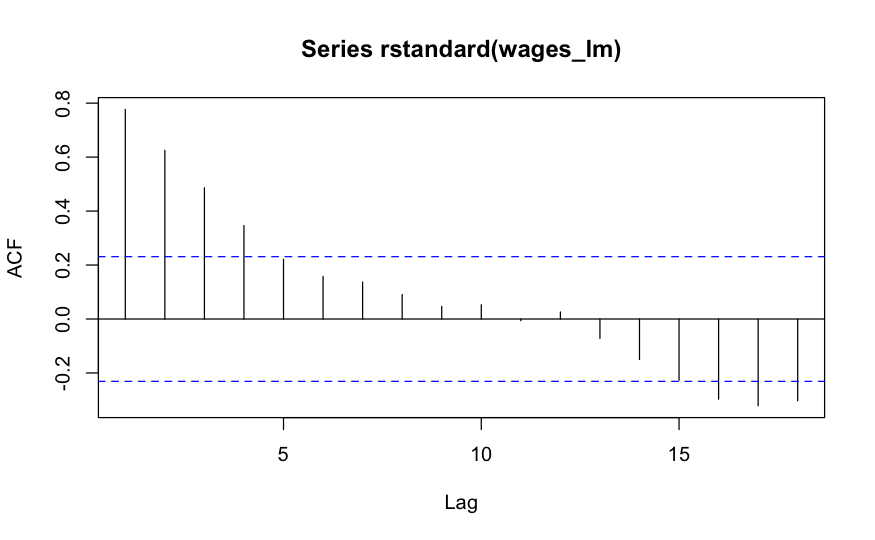

```r
acf(rstandard(wages_lm))
```

Here’s the ACF of the seasonal difference of the first difference of the logged series for air passengers.

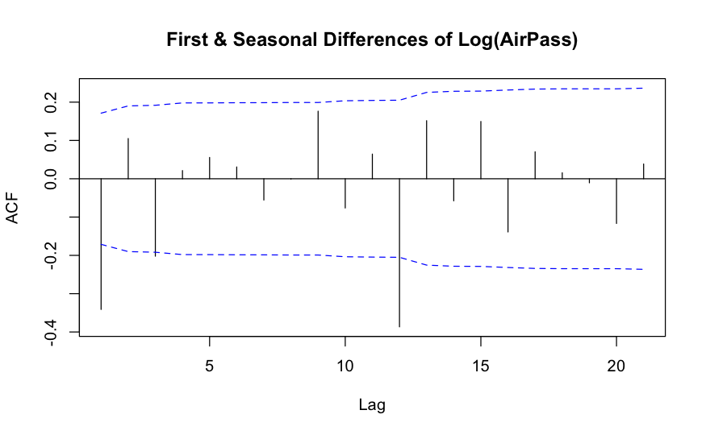

```r
acf(as.vector(diff(diff(log(airpass)),lag=12)),ci.type='ma',
main='First & Seasonal Differences of Log(AirPass)')
```

Although there is a slightly significant autocorrelation at lag 3, the most prominent autocorrelations are at lags 1 and 12.

Let’s fit a seasonal ARIMA model to the logged series.

```r
model_arima
```

```
Call:
arima(x = log(airpass), order = c(0, 1, 1), seasonal = list(order = c(0, 1,
    1), period = 12))

Coefficients:
          ma1     sma1
      -0.4018  -0.5569
s.e.   0.0896   0.0731

sigma^2 estimated as 0.001348:  log likelihood = 244.7,  aic = -485.4
```

### FORECASTING

Now that we’ve fit the data, we’d like to be able to use our model to make forecasts, or predictions. Let’s produce forecasts for this series with a lead time of 2 years.

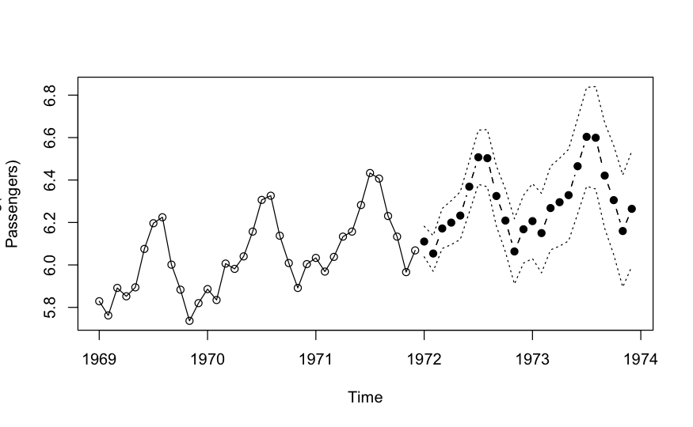

```r
plot(model_arima,n1=c(1969,1),n.ahead=24,pch=19,ylab='Log(Air
Passengers)')
```

The forecasts follow the seasonal and upward trend of the time series nicely. The forecast limits provide us with a clear measure of the uncertainty in the forecasts. We can also plot the forecasts and limits in original terms.

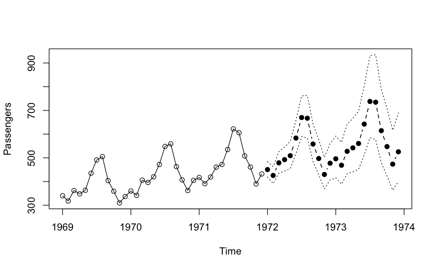

```r
plot(model_arima,n1=c(1969,1),n.ahead=24,pch=19,ylab='Air
Passengers',transform=exp)
```

In original terms, it is easier to see that the forecast limits spread out as we get further into the future.